# Course Project - Modeling Data in the Tidyverse

dillonchewwx

15/03/2021

# Overview

In this project, the consumer complains data from the [Consumer Complaint Database](https://www.consumerfinance.gov/data-research/consumer-complaints/) (CFPB) would be used. The CFPB is an independent agency of the United States government that promotes transparency and protects consumers by providing information needed to make decisions when choosing financial institutions including banking institutions, lenders, mortgage services, credit unions, securities firms, foreclosure services, and debt collectors. One of the purposes of the agency is to receive and process complaints and questions about consumer financial products and services.

When a complaint is submitted by a consumer, the CFPB has to determine which category the complaint falls in (e.g. “Mortgage”, “Student loan”, etc). In this project, the goal would be to build a classification algorithm to classify consumer complaints into one of four categories: “Credit card or prepaid card”, “Mortgage”, “Student loan”, or “Vehicle loan or lease”.

The datasets can be downloaded from the course website:

- [Training Data](https://www.coursera.org/learn/tidyverse-modelling-data/home/welcome)
- [Testing Data](https://www.coursera.org/learn/tidyverse-modelling-data/home/welcome)

# Data Import

```r
library(tidyverse) # for data frame manipulation
library(tidymodels) # for ML
library(tm) # for text manipulation
df<-read_csv("../data_complaints_train.csv")
```

## Data Inspection

```r
glimpse(df)
```

```
## Rows: 90,975
## Columns: 6
## $ Product                        <chr> "Credit card or prepaid card", "Mortgag~
## $ `Consumer complaint narrative` <chr> "I initially in writing to Chase Bank i~
## $ Company                        <chr> "JPMORGAN CHASE & CO.", "Ditech Financi~
## $ State                          <chr> "CT", "GA", "IN", "MI", "MI", "FL", "WA~
## $ `ZIP code`                     <chr> "064XX", "None", "463XX", "490XX", "480~
## $ `Submitted via`                <chr> "Web", "Web", "Web", "Web", "Web", "Web~
```

A quick look of the data reveals the following:

- The outcome variable which we are interested in is called `Product`.
- Although there are 5 variables which can be used as predictors, the `Consumer complaint narrative` variable seems to provide the most relevant information for making predictions on the product category.

Thus, we shall only select the above two variables for further processing.

```r
# Rename the complaint column and only select the two variables
df<-df %>%
    rename(Complain=`Consumer complaint narrative`) %>%
    select(Product, Complain)
```

# Data Pre-processing

Let’s take a closer look at each of the variables.

```r
# Check if there are any categories
unique(df$Product)
```

```
## [1] "Credit card or prepaid card" "Mortgage"
## [3] "Student loan"                "Vehicle loan or lease"
```

```r
# Check the first few rows of Complain
head(df$Complain)
```

```
## [1] "I initially in writing to Chase Bank in late XXXX about a charge that was unauthorized on XXXX from XXXX in the amount of {$790.00} after many letters and complaints they still did not do anything yet in XXXX they closed my original account and reissued a new account and sent me a letter ind…
## [2] "My ex husband and myself had a mobile home ( Home Mortgage ) with XXXX XXXX back in XX/XX/XXXX. I went through a horrible divorce as my husband was using drugs and failing to pay the bills which led to my having to divorce him. The Mortgage was in both of our names. We only had the Mortgage …
## [3] "I was a student at XXXX XXXX from XX/XX/XXXX-XX/XX/XXXX. I accumulated XXXX of debt in student loans. This school flat out lied to me. I was under the assumption it would have been less than half of that since I had a lot of credits that transferred, not to mention this school promised me jo…
## [4] "It has come to my attention the CITI group is actively attempting to interfere with rights guaranteed by the Constitution ( 2nd Amendment ) by manipulating or denying service to certain entities or transactions that are protected by the Constitution. I do not expect CITI group, or any other …
## [5] "This banks new firearm policies run counter to laws and regulations passed by Congress, and they infringe and discriminate against an individuals Second Amendment rights. Such policies, should not be endorsed by our federal government, which instead should do business with companies that res…
## [6] "I only use my walmart store card to keep from having it cancelled. My sons a college student had his card cancelled for non use. I made a small purchase in XX/XX/XXXX and paid it off. Made another small purchase in XX/XX/XXXX and thought i paid it off online via wlamart.com but that seemed n…
```

It appears that `Product` only has 4 categories. We can make it into a factor. However for `Complain`, it is a long narrative which is much more complicated and thus we have to clean it up. We will carry out the following clean-up process:

1. Drop any rows with `NA` in the column.
2. Remove any strings such as “XX”, “XXX” and “XXXX” which were used to mask private information and dates.
3. Convert all letters to lower case.
4. Remove any numbers.
5. Remove all punctuation.
6. Remove escape characters and white spaces: `\t` and `\n`.
7. Remove stop words e.g. “I”, “My”, “which”, “won’t” etc..

```r
df_clean<-df %>%
    filter(Complain!=is.na(.)) %>%
    mutate(Complain=gsub("[XX]+", "", Complain)) %>%
    mutate(Complain=str_to_lower(Complain)) %>%
    mutate(Complain=gsub("[0-9]", "", Complain)) %>%
    mutate(Complain=removePunctuation(Complain)) %>%
    mutate(Complain=gsub("\n", "", Complain)) %>%
    mutate(Complain=gsub("\t", "", Complain)) %>%
    mutate(Complain=stripWhitespace(Complain))
complains<-Corpus(VectorSource(df_clean$Complain)) %>%
    tm_map(removeWords, stopwords())
```

We will now create a document term matrix using the `tm` package where each complaint will be a “document” occupying a row, each “term” will be a column name, and the counts of each term per document will be the values.

```r
dtm<-DocumentTermMatrix(complains)
inspect(dtm)
```

```
## <<DocumentTermMatrix (documents: 90975, terms: 81653)>>
## Non-/sparse entries: 7048327/7421333348
## Sparsity           : 100%
## Maximal term length: 2229
## Weighting          : term frequency (tf)
## Sample             :
##        Terms
## Docs    account bank card credit loan mortgage payment payments received told
##   19650       4   34    0      3   49       10       6        7       12    0
##   25455      79    2    0     11   80       57      29        4        3    0
##   27671       2    1    0      1    4        4       8        5        1    0
##   33614       2   32    2      6    1       12       1        0        3    0
##   64243       0    0    0      0   26       15       1       10        4    2
##   68621       9    0    0     10   56        0      16        9       10    8
##   70389       1    0    0      3    2       26       0        3        0    0
##   73540       8    1    0      6   33       61       7       37        3    0
##   77518       0    0    0      0  103        0      45        1        0    2
##   84551      36    0    0      8   68       60      22       16        0    0
```

We note that there are 90975 documents and 81653 terms - that’s huge! We shall try to reduce our data set initially by keeping only the relevant terms for exploratory analysis. Here, we define relevant terms as terms which appear 1000 times or more.

```r
# Find terms which appear 1000 times or more
freqTerms<-findFreqTerms(dtm, lowfreq=1000)
# Limit DTM to only contain terms that appear 1000 times or more.
dtm<-DocumentTermMatrix(complains, list(dictionary=freqTerms))
inspect(dtm)
```

```
## <<DocumentTermMatrix (documents: 90975, terms: 1552)>>
## Non-/sparse entries: 5708981/135484219
## Sparsity           : 96%
## Maximal term length: 15
## Weighting          : term frequency (tf)
## Sample             :
##        Terms
## Docs    account bank card credit loan mortgage payment payments received told
##   11002       1    5    0      1   68       42       4        4       10    1
##   11343       4    0    1      9   30        6       7        1        2   57
##   19650       4   34    0      3   49       10       6        7       12    0
##   25436      67    6    0      9   86       61      25        3        5    0
##   25455      79    2    0     11   80       57      29        4        3    0
##   60769       0    0    6      5   43        6       7        4       27   18
##   64243       0    0    0      0   26       15       1       10        4    2
##   68621       9    0    0     10   56        0      16        9       10    8
##   73540       8    1    0      6   33       61       7       37        3    0
##   84551      36    0    0      8   68       60      22       16        0    0
```

We have reduced the number of terms to 1552, but the sparsity has dropped marginally to 96%. Let’s further simplify by removing sparse terms which have at least 95% of sparse elements (i.e, terms only occurring 0 times in a document) which can help to reduce the matrix without losing significant relations inherent to the matrix.

```r
dtm<-removeSparseTerms(dtm, 0.95)
inspect(dtm)
```

```
## <<DocumentTermMatrix (documents: 90975, terms: 341)>>
## Non-/sparse entries: 3548325/27474150
## Sparsity           : 89%
## Maximal term length: 14
## Weighting          : term frequency (tf)
## Sample             :
##        Terms
## Docs    account bank card credit loan mortgage payment payments received told
##   11002       1    5    0      1   68       42       4        4       10    1
##   11343       4    0    1      9   30        6       7        1        2   57
##   25455      79    2    0     11   80       57      29        4        3    0
##   37990      12    6    0     11   41        6       6        4       29    9
##   56802      18    7    0      0    6       20      17       17       21    8
##   60769       0    0    6      5   43        6       7        4       27   18
##   64243       0    0    0      0   26       15       1       10        4    2
##   68621       9    0    0     10   56        0      16        9       10    8
##   70174       8    1    0      7   41        5      59       32        5    9
##   84551      36    0    0      8   68       60      22       16        0    0
```

We have reduced the number of terms to 341, and the sparsity is now 89%. Following which, lets now carry out some simple exploratory analysis on the dataset. We can start by finding out the top 150 terms.

```r
# Convert to Matrix for further processing
dtm_mat<-as.matrix(dtm)

# Get the total number of counts for each term and show the top 150 terms
sumTerm<-colSums(dtm_mat) %>%
    .[order(-.)]
head(sumTerm, 150)
```

```
##        payment         credit        account           loan           card
##         125209         123231         117566         116300          93671
##           told       mortgage       payments       received           bank
##          76344          73598          73240          67255          63024
##           time         called            one            pay        company
##          62293          61445          52298          51811          51569
##           back            due            get           will           made
##          50662          49787          48903          48615          48526
##          never           said            can           call         amount
##          47774          45900          45510          44637          44617
##           paid    information           sent       interest            now
##          44542          42565          42548          42043          40050
##         letter           also           late        balance           home
##          39799          39453          39253          38122          36074
##          since           days           make          month          phone
##          35532          34912          34029          33346          33049
##          asked          still          money         months            new
##          32690          31371          31006          29746          29102
##           even        service          email         number       customer
##          28717          28081          27621          27604          26921
##          years           date           help          loans          check
##          26660          26045          25725          25575          25024
##           just      statement          first         charge        another
##          24582          23808          22992          22745          22681
##        request         report          chase        charges           fees
##          22511          22450          22237          22001          21947
##          times         stated      contacted            day      insurance
##          21883          21656          21563          21552          21435
##          issue            two      complaint            see            fee
##          21151          21099          20936          20663          20596
##           need        process         escrow           know           like
##          20144          19818          19747          19565          19369
##        monthly       property         closed      documents          spoke
##          19358          19242          19003          18996          18875
##           year   modification         please        applied        dispute
##          18740          18528          18504          18354          18296
##      requested representative        contact           take            car
##          18258          18064          18009          17853          17835
##           want          going      financial        without           send
##          17745          17662          17501          17237          17233
##           last            got        however        receive           rate
##          17183          17168          17066          16982          16894
##        several     department          fraud           went           able
##          16876          16811          16792          16675          16662
##           full        charged         online           work          didnt
##          16627          16573          16342          15917          15843
##         paying       provided           dont          every       informed
##          15769          15652          15634          15593          15522
##       business    application           well          tried           name
##          15295          15063          14718          14641          14520
##        provide        stating            put        address         refund
##          14519          14308          14307          14138          14011
##       response         trying           case          later           bill
##          13969          13927          13613          13587          13498
##          calls           mail         needed       purchase        nothing
##          13459          13452          13419          13373          13225
##          today           past            way           done        current
##          13079          13001          12862          12792          12715
##           debt          funds           used        closing           took
##          12707          12701          12637          12577          12551
```

It appears that there are several other frequent words in the top 150 which may not add value to the data set e.g. “told”, “called”, “back”, “get”, “will” etc. Let’s remove them to make the data cleaner.

```r
extraStopWords<-c("told", "called", "back", "get", "will", "never", "said", "can", "call", "now", "also",
                  "even", "just", "like", "please", "take", "want", "going", "without", "got", "however",
                  "went", "able", "didnt", "dont", "put", "later", "way", "done", "needed", "today", "used", "took")
complains<-tm_map(complains, removeWords, extraStopWords)
```

Now, we shall recreate the DTM, but with all the additional filters.

```r
# Create a new DTM with all previous filters.
dtm<-DocumentTermMatrix(complains, list(dictionary=freqTerms))
inspect(dtm)
```

```
## <<DocumentTermMatrix (documents: 90975, terms: 1552)>>
## Non-/sparse entries: 5138413/136054787
## Sparsity           : 96%
## Maximal term length: 15
## Weighting          : term frequency (tf)
## Sample             :
##        Terms
## Docs    account bank card credit loan mortgage payment payments received time
##   11002       1    5    0      1   68       42       4        4       10   10
##   19650       4   34    0      3   49       10       6        7       12    5
##   25436      67    6    0      9   86       61      25        3        5    2
##   25455      79    2    0     11   80       57      29        4        3    3
##   60769       0    0    6      5   43        6       7        4       27    9
##   64243       0    0    0      0   26       15       1       10        4   20
##   68621       9    0    0     10   56        0      16        9       10   15
##   73540       8    1    0      6   33       61       7       37        3    2
##   84551      36    0    0      8   68       60      22       16        0    8
##   9878        2    6    0      0   16       16      13        1       13    4
```

```r
dtm<-removeSparseTerms(dtm, 0.95)
inspect(dtm)
```

```
## <<DocumentTermMatrix (documents: 90975, terms: 308)>>
## Non-/sparse entries: 2977757/25042543
## Sparsity           : 89%
## Maximal term length: 14
## Weighting          : term frequency (tf)
## Sample             :
##        Terms
## Docs    account bank card credit loan mortgage payment payments received time
##   11002       1    5    0      1   68       42       4        4       10   10
##   15879       2   73    0      0   19       12       2        6       38    6
##   19650       4   34    0      3   49       10       6        7       12    5
##   25436      67    6    0      9   86       61      25        3        5    2
##   25455      79    2    0     11   80       57      29        4        3    3
##   56802      18    7    0      0    6       20      17       17       21   12
##   60769       0    0    6      5   43        6       7        4       27    9
##   64243       0    0    0      0   26       15       1       10        4   20
##   68621       9    0    0     10   56        0      16        9       10   15
##   84551      36    0    0      8   68       60      22       16        0    8
```

We have reduced the number of terms to 308.

# Building a ML model for predicting product category

## Create Train and Test Sets

As we have briefly processed the “train” data set as dtm previously, we would now need to split it into training (75%) and test (25%) sets. Let’s start by creating the training data set.

```r
# Convert Product to a factor
df_clean<-df_clean %>%
    mutate(Product=factor(Product))

# Convert dtm_mat into a data frame and add the outcome Product column.
dtm_mat<-as.matrix(dtm)
dtm_train<-dtm_mat %>%
    as.matrix() %>%
    as.data.frame() %>%
    bind_cols(Product=df_clean$Product) %>%
    select(Product, everything())

# Create the training data set
set.seed(1234)
split_dtm<-initial_split(dtm_train, strata=Product, prop=3/4)
training_dtm<-training(split_dtm)
head(training_dtm)
```

```
##                       Product account almost amount anything bank card case
## 1 Credit card or prepaid card       2      1      1        2    1    1    1
## 2                    Mortgage       0      0      1        0    0    0    0
## 3                Student loan       0      0      0        0    0    0    0
## 4 Credit card or prepaid card       0      0      0        0    0    0    0
## 5 Credit card or prepaid card       0      0      0        0    0    0    0
## 6 Credit card or prepaid card       3      0      0        0    0    2    0
##   charge charged charges chase closed feel fraud getting immediately interest
## 1      3       1       1     2      1    1     1       1           1        1
## 2      0       1       0     0      0    0     0       0           0        0
## 3      0       0       0     0      0    1     0       0           0        0
## 4      0       0       0     0      0    0     0       0           0        0
## 5      0       0       0     0      0    0     0       0           0        0
## 6      0       0       0     0      0    0     0       0           1        0
##   last late letter make many months new original pay sent statement stating
```

[output cut: 195 more lines]

```r
count(training_dtm, Product)
```

```
##                       Product     n
## 1 Credit card or prepaid card 28721
## 2                    Mortgage 23218
## 3                Student loan  9364
## 4       Vehicle loan or lease  6930
```

We shall do the same for the testing data set.

```r
testing_dtm<-testing(split_dtm)
head(testing_dtm)
```

```
##                        Product account almost amount anything bank card case
## 10       Vehicle loan or lease       5      1      0        0    0    1    0
## 11                    Mortgage       0      0      0        0    6    0    0
## 13                Student loan       0      0      0        0    0    0    0
## 18 Credit card or prepaid card       3      0      1        0    3    5    1
## 20       Vehicle loan or lease       0      0      1        0    0    0    1
## 23                    Mortgage       0      0      0        0    0    0    0
##    charge charged charges chase closed feel fraud getting immediately interest
## 10      0       0       0     0      0    0     0       0           2        0
## 11      0       0       0     0      0    0     0       0           0        0
## 13      0       0       0     0      0    0     0       0           0        0
## 18      1       0       0     0      4    0     0       0           1        0
## 20      1       0       1     0      0    0     0       0           1        0
## 23      0       0       0     0      0    0     0       0           0        0
##    last late letter make many months new original pay sent statement stating
```

[output cut: 195 more lines]

```r
count(testing_dtm, Product)
```

```
##                       Product    n
## 1 Credit card or prepaid card 9573
## 2                    Mortgage 7739
## 3                Student loan 3121
## 4       Vehicle loan or lease 2309
```

## Create cross validation folds.

Before moving on, we can also create cross validation folds with `rsample`. We will carry out a 10-fold cross-validation.

```r
vfold_dtm<-vfold_cv(data=training_dtm, v=10)
vfold_dtm
```

```
## #  10-fold cross-validation
## # A tibble: 10 x 2
##    splits               id
##    <list>               <chr>
##  1 <split [61409/6824]> Fold01
##  2 <split [61409/6824]> Fold02
##  3 <split [61409/6824]> Fold03
##  4 <split [61410/6823]> Fold04
##  5 <split [61410/6823]> Fold05
##  6 <split [61410/6823]> Fold06
##  7 <split [61410/6823]> Fold07
##  8 <split [61410/6823]> Fold08
##  9 <split [61410/6823]> Fold09
## 10 <split [61410/6823]> Fold10
```

```r
pull(vfold_dtm, splits)
```

```
## [[1]]
## <Analysis/Assess/Total>
## <61409/6824/68233>
##
## [[2]]
## <Analysis/Assess/Total>
## <61409/6824/68233>
##
## [[3]]
## <Analysis/Assess/Total>
## <61409/6824/68233>
##
## [[4]]
## <Analysis/Assess/Total>
## <61410/6823/68233>
##
## [[5]]
## <Analysis/Assess/Total>
## <61410/6823/68233>
##
## [[6]]
## <Analysis/Assess/Total>
## <61410/6823/68233>
##
## [[7]]
## <Analysis/Assess/Total>
## <61410/6823/68233>
##
## [[8]]
## <Analysis/Assess/Total>
## <61410/6823/68233>
##
## [[9]]
## <Analysis/Assess/Total>
## <61410/6823/68233>
##
## [[10]]
## <Analysis/Assess/Total>
## <61410/6823/68233>
```

```r
# Check first fold
first_fold<-vfold_dtm$splits[[1]]
# Training set of this fold
head(as.data.frame(first_fold, data="analysis"))
```

```
##                       Product account almost amount anything bank card case
## 1 Credit card or prepaid card       2      1      1        2    1    1    1
## 2                    Mortgage       0      0      1        0    0    0    0
## 3                Student loan       0      0      0        0    0    0    0
## 4 Credit card or prepaid card       0      0      0        0    0    0    0
## 5 Credit card or prepaid card       0      0      0        0    0    0    0
## 6 Credit card or prepaid card       3      0      0        0    0    2    0
##   charge charged charges chase closed feel fraud getting immediately interest
## 1      3       1       1     2      1    1     1       1           1        1
## 2      0       1       0     0      0    0     0       0           0        0
## 3      0       0       0     0      0    1     0       0           0        0
## 4      0       0       0     0      0    0     0       0           0        0
## 5      0       0       0     0      0    0     0       0           0        0
## 6      0       0       0     0      0    0     0       0           1        0
##   last late letter make many months new original pay sent statement stating
```

[output cut: 195 more lines]

```r
# Test set of this fold
head(as.data.frame(first_fold, data="assessment"))
```

```
##                         Product account almost amount anything bank card case
## 43  Credit card or prepaid card       0      0      0        0    0    0    0
## 50  Credit card or prepaid card       1      0      2        0    8    1    0
## 63                     Mortgage       0      0      0        0    0    0    0
## 88                 Student loan       0      0      1        1    0    0    0
## 92  Credit card or prepaid card       0      0      2        1    0    6    0
## 104 Credit card or prepaid card       1      0      1        0    0    0    0
##     charge charged charges chase closed feel fraud getting immediately interest
## 43       0       0       0     0      0    0     0       0           0        0
## 50       0       1       2     0      0    0     0       0           0        0
## 63       0       0       0     0      0    0     0       0           2        0
## 88       0       0       0     0      0    0     0       0           0        0
## 92       0       0       0     0      0    0     0       0           0        0
## 104      0       0       0     0      0    0     0       1           0        0
##     last late letter make many months new original pay sent statement stating
```

[output cut: 202 more lines]

## Creating ML workflow

We can now create a recipe, model, and workflow for the ML model. We will use a classification decision tree model (`rpart` engine) as our variable is categorical.

```r
# Create a recipe
dtm_recipe<-training_dtm %>%
    recipe(Product~.)

# Create a model
dtm_model<-decision_tree() %>%
    set_mode("classification") %>%
    set_engine("rpart")
dtm_model
```

```
## Decision Tree Model Specification (classification)
##
## Computational engine: rpart
```

```r
# Create a workflow
dtm_workflow<-workflow() %>%
    add_recipe(dtm_recipe) %>%
    add_model(dtm_model)
dtm_workflow
```

```
## == Workflow ====================================================================
## Preprocessor: Recipe
## Model: decision_tree()
##
## -- Preprocessor ----------------------------------------------------------------
## 0 Recipe Steps
##
## -- Model -----------------------------------------------------------------------
## Decision Tree Model Specification (classification)
##
## Computational engine: rpart
```

## Fit and assess model performance

Now that the setup is done, we shall attempt to fit the workflow.

```r
# Fit without cross validation
dtm_fit<-fit(dtm_workflow, data=training_dtm)
dtm_workflow_fit<-dtm_fit %>%
    pull_workflow_fit()
dtm_workflow_fit
```

```
## parsnip model object
##
## Fit time:  27.9s
## n= 68233
##
## node), split, n, loss, yval, (yprob)
##       * denotes terminal node
##
##   1) root 68233 39512 Credit card or prepaid card (0.420925359 0.340275233 0.137235648 0.101563759)
##     2) mortgage< 0.5 51003 22686 Credit card or prepaid card (0.555202635 0.131443248 0.179734525 0.133619591)
##       4) card>=0.5 20773   604 Credit card or prepaid card (0.970923795 0.005680451 0.011842295 0.011553459) *
##       5) card< 0.5 30230 21309 Student loan (0.269533576 0.217863050 0.295104201 0.217499173)
##        10) student< 0.5 25944 17819 Credit card or prepaid card (0.313174530 0.253122109 0.181236509 0.252466852)
##          20) car< 0.5 22648 14640 Credit card or prepaid card (0.353585306 0.287398446 0.204874603 0.154141646)
##            40) loan< 0.5 13944  6353 Credit card or prepaid card (0.544391853 0.193703385 0.130593804 0.131310958)
##              80) loans< 0.5 13204  5629 Credit card or prepaid card (0.573689791 0.196455620 0.093683732 0.136170857)
##               160) escrow< 0.5 12746  5176 Credit card or prepaid card (0.593911815 0.168052722 0.097050055 0.140985407) *
##               161) escrow>=0.5 458     6 Mortgage (0.010917031 0.986899563 0.000000000 0.002183406) *
##              81) loans>=0.5 740   156 Student loan (0.021621622 0.144594595 0.789189189 0.044594595) *
##            41) loan>=0.5 8704  4896 Mortgage (0.047909007 0.437500000 0.323874081 0.190716912)
##              82) home>=0.5 1726   188 Mortgage (0.011587486 0.891077636 0.044032445 0.053302433) *
##              83) home< 0.5 6978  4235 Student loan (0.056893093 0.325308111 0.393092577 0.224706220)
##               166) loans< 0.5 5547  3426 Mortgage (0.070127997 0.382368848 0.281954209 0.265548945) *
##               167) loans>=0.5 1431   252 Student loan (0.005590496 0.104122991 0.823899371 0.066387142) *
##          21) car>=0.5 3296   237 Vehicle loan or lease (0.035497573 0.017597087 0.018810680 0.928094660) *
##        11) student>=0.5 4286    67 Student loan (0.005366309 0.004433038 0.984367709 0.005832944) *
##     3) mortgage>=0.5 17230   716 Mortgage (0.023447475 0.958444573 0.011433546 0.006674405) *
```

```r
dtm_workflow_fit$fit$variable.importance
```

```
##     mortgage         card         loan      student         home       escrow
## 13022.539833  8121.493156  3328.579838  3172.341466  2619.200304  2359.487061
##          car       credit     property        loans modification  foreclosure
##  2323.668037  2206.991232  1900.096642  1809.184200  1594.478808  1580.100621
##      charges        cards          use    servicing  application      federal
##   953.951923   948.478429   938.313367   143.065321   121.498758    26.002335
##      program        years      closing     payments    situation        house
##    20.499412    18.439810    13.282531     8.881964     7.754960     7.590018
##        close       wanted         plan    financial      company      getting
##     6.072014     5.639971     5.277753     4.934975     2.819985     2.114989
##    insurance
##     1.003036
```

Here, we can see that `mortgage`, `card` and `loan` were the most important words for predicting Product. Following this, we can perform some predictions.

```r
predict_Product<-predict(dtm_workflow_fit, new_data=training_dtm)
accuracy(training_dtm, truth=Product, estimate=predict_Product$.pred_class)
```

```
## # A tibble: 1 x 3
##   .metric  .estimator .estimate
##   <chr>    <chr>          <dbl>
## 1 accuracy multiclass     0.841
```

```r
# Breakdown of Product
count(training_dtm, Product)
```

```
##                       Product     n
## 1 Credit card or prepaid card 28721
## 2                    Mortgage 23218
## 3                Student loan  9364
## 4       Vehicle loan or lease  6930
```

```r
# Breakdown of Predicted Product
count(predict_Product, .pred_class)
```

```
## # A tibble: 4 x 2
##   .pred_class                     n
## * <fct>                       <int>
## 1 Credit card or prepaid card 33519
## 2 Mortgage                    24961
## 3 Student loan                 6457
## 4 Vehicle loan or lease        3296
```

```r
# Show which rows were predicted correctly
predicted_and_truth<-bind_cols(training_dtm, predicted_Product=pull(predict_Product, .pred_class)) %>%
    select(predicted_Product, everything())
head(predicted_and_truth)
```

```
##             predicted_Product                     Product account almost amount
## 1 Credit card or prepaid card Credit card or prepaid card       2      1      1
## 2                    Mortgage                    Mortgage       0      0      1
## 3                Student loan                Student loan       0      0      0
## 4 Credit card or prepaid card Credit card or prepaid card       0      0      0
## 5 Credit card or prepaid card Credit card or prepaid card       0      0      0
## 6 Credit card or prepaid card Credit card or prepaid card       3      0      0
##   anything bank card case charge charged charges chase closed feel fraud
## 1        2    1    1    1      3       1       1     2      1    1     1
## 2        0    0    0    0      0       1       0     0      0    0     0
## 3        0    0    0    0      0       0       0     0      0    1     0
## 4        0    0    0    0      0       0       0     0      0    0     0
## 5        0    0    0    0      0       0       0     0      0    0     0
## 6        0    0    2    0      0       0       0     0      0    0     0
##   getting immediately interest last late letter make many months new original
```

[output cut: 195 more lines]

The accuracy is about 84.1%. Seems pretty alright on the first go. We also note that extra “Credit card or prepaid card” and “Mortgage” was predicted, while “Student loan” and “Vehicle loan or lease” was under predicted. Additionally, we can also see exactly which rows resulted in incorrect predictions.

Lets now try to fit the model to our cross validation folds.

```r
set.seed(122)
resample_fit<-fit_resamples(dtm_workflow, vfold_dtm)
collect_metrics(resample_fit)
```

```
## # A tibble: 2 x 6
##   .metric  .estimator  mean     n  std_err .config
##   <chr>    <chr>      <dbl> <int>    <dbl> <chr>
## 1 accuracy multiclass 0.841    10 0.00128  Preprocessor1_Model1
## 2 roc_auc  hand_till  0.929    10 0.000905 Preprocessor1_Model1
```

Interestingly, the model accuracy stays the same.

## Tuning the model

Now, lets try to improve the model by tuning a hyperparameter.

```r
# Create tuned model
dtm_model_tune<-decision_tree(cost_complexity=tune(), tree_depth=tune()) %>%
    set_mode("classification") %>%
    set_engine("rpart")

tree_grid<-grid_regular(cost_complexity(), tree_depth(), levels=3)

# Create workflow
dtm_workflow_tune<-workflow() %>%
    add_recipe(dtm_recipe) %>%
    add_model(dtm_model_tune)

# Use multiple cores for faster run time.
doParallel::registerDoParallel(cores=0.75*parallel::detectCores())

# Perform tuning
set.seed(123)
model_resample_fit<-tune_grid(dtm_workflow_tune,
                              resamples=vfold_dtm,
                              grid=tree_grid,
                              metrics=metric_set(accuracy, roc_auc))

# Assess Performance
show_best(model_resample_fit, metric="accuracy")
```

```
## # A tibble: 5 x 8
##   cost_complexity tree_depth .metric  .estimator  mean     n std_err .config
##             <dbl>      <int> <chr>    <chr>      <dbl> <int>   <dbl> <chr>
## 1    0.0000000001         15 accuracy multiclass 0.881    10 6.00e-4 Preprocess~
## 2    0.00000316           15 accuracy multiclass 0.881    10 6.00e-4 Preprocess~
## 3    0.0000000001          8 accuracy multiclass 0.854    10 1.03e-3 Preprocess~
## 4    0.00000316            8 accuracy multiclass 0.854    10 1.03e-3 Preprocess~
## 5    0.0000000001          1 accuracy multiclass 0.657    10 1.50e-3 Preprocess~
```

The highest accuracy achieved has gone up to 88.1%. Let’s stop the model building here and just update `dtm_workflow_tune` with the values chosen by `select_best()`.

```r
# Specify min_n value
tuned_values<-select_best(model_resample_fit,"accuracy")
# Finalize model/workflow
dtm_workflow_tuned<-dtm_workflow_tune %>%
    finalize_workflow(tuned_values)
```

# Final Model Performance Evaluation

We shall fit the final model on the full training set using the `last_fit()` function.

```r
# Fit final model on the full training set
overall_fit<-last_fit(dtm_workflow_tuned, split_dtm)
collect_metrics(overall_fit)
```

```
## # A tibble: 2 x 4
##   .metric  .estimator .estimate .config
##   <chr>    <chr>          <dbl> <chr>
## 1 accuracy multiclass     0.881 Preprocessor1_Model1
## 2 roc_auc  hand_till      0.962 Preprocessor1_Model1
```

The accuracy is approximately 88.1%.

Let’s take a look at the predicted values for the test set.

```r
test_predictions<-collect_predictions(overall_fit)
head(test_predictions)
```

```
## # A tibble: 6 x 9
##   id     `.pred_Credit c~ .pred_Mortgage `.pred_Student ~ `.pred_Vehicle ~  .row
##   <chr>             <dbl>          <dbl>            <dbl>            <dbl> <int>
## 1 train~         0.745           0.0755           0.0566           0.123      10
## 2 train~         0.000902        0.996            0.00205          0.00148    11
## 3 train~         0.00429         0.00238          0.991            0.00214    13
## 4 train~         0.994           0.00150          0.00181          0.00253    18
## 5 train~         0.0412          0.0105           0.0167           0.932      20
## 6 train~         0.000902        0.996            0.00205          0.00148    23
## # ... with 3 more variables: .pred_class <fct>, Product <fct>, .config <chr>
```

We can do a plot to better visualize the predictions.

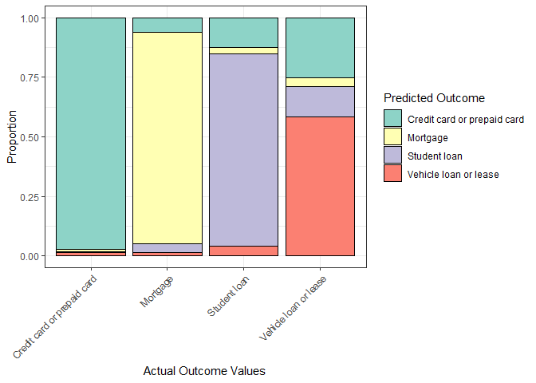

```r
ggplot(test_predictions, aes(x=Product, fill=.pred_class)) +
    geom_bar(position="fill", color="black") +
    scale_fill_brewer(palette="Set3") +
    labs(x="Actual Outcome Values",
         y="Proportion",
         fill="Predicted Outcome") +
    theme_bw() +
    theme(axis.text.x=element_text(angle=45, hjust=1, vjust=1))
```

It appears that our model does relatively well on all outcomes except for “Vehicle loan or lease”.

# Predicting outcomes for the the provided test data

Let’s start by loading the data and doing some pre-processing.

```r
# Load and clean up the data
df_test<-read_csv("../data_complaints_test.csv") %>%
    rename(Complain=`Consumer complaint narrative`) %>%
    select(Complain) %>%
    mutate(Complain=gsub("[XX]+", "", Complain)) %>%
    mutate(Complain=str_to_lower(Complain)) %>%
    mutate(Complain=gsub("[0-9]", "", Complain)) %>%
    mutate(Complain=removePunctuation(Complain)) %>%
    mutate(Complain=gsub("\n", "", Complain)) %>%
    mutate(Complain=gsub("\t", "", Complain)) %>%
    mutate(Complain=stripWhitespace(Complain))
# Make corpus
test_complains<-Corpus(VectorSource(df_test$Complain)) %>%
    tm_map(removeWords, stopwords())
# Make DTM
dtm_test<-DocumentTermMatrix(test_complains, list(dictionary=freqTerms))
dtm_test_mat<-dtm_test %>%
    as.matrix() %>%
    as.data.frame()
head(dtm_test_mat)
```

```
##   also contacting credit deferred due file inform late loan missed multiple
## 1    1          1      2        1   2    1      1    1    2      1        1
## 2    0          0      0        0   1    0      0    0    0      0        0
## 3    0          0      0        0   0    0      0    0    3      0        0
## 4    1          0      0        0   0    0      0    0    0      1        1
## 5    0          0      0        0   0    0      0    1    1      0        0
## 6    0          0      3        0   0    0      0    0    0      0        0
##   never payments period properly received regards report reporting statements
## 1     1        3      1        1        1       1      1         1          1
## 2     1        0      0        0        0       0      0         0          0
## 3     1        1      0        0        0       0      0         0          0
## 4     0        1      1        0        0       0      0         0          4
## 5     1        0      0        0        0       0      0         0          0
## 6     1        0      0        0        2       0      0         0          0
##   time able ask behind business call calling came can car check claim come
```

[output cut: 1105 more lines]

Now its time to make predictions!

```r
final_model<-fit(dtm_workflow_tuned, dtm_train)
predict(final_model, new_data=dtm_test_mat)
```

```
## # A tibble: 20 x 1
##    .pred_class
##    <fct>
##  1 Vehicle loan or lease
##  2 Vehicle loan or lease
##  3 Student loan
##  4 Mortgage
##  5 Student loan
##  6 Credit card or prepaid card
##  7 Credit card or prepaid card
##  8 Credit card or prepaid card
##  9 Student loan
## 10 Vehicle loan or lease
## 11 Student loan
## 12 Mortgage
## 13 Credit card or prepaid card
## 14 Credit card or prepaid card
## 15 Mortgage
## 16 Credit card or prepaid card
## 17 Mortgage
## 18 Student loan
## 19 Vehicle loan or lease
## 20 Mortgage
```